# Homework 1: Trend Following

## Name: Jon Knapp

## Class: EE522 Discrete Time Processing

### Problem 1: Time domain plot of original signal and filtered signal. Please use good figure hygiene.

```python
"""
Historical stock data is needed. Since finance.yahoo.com has put downloading historical data behind a paywall, downloading
the data using the yfinance package is needed.
This homework assignment will use Nike stock (NKE) starting at 1994 (Nike went public in 1980).
This duration will cover the 2000 dot-com crash, the 2008 recession, and COVID.
"""
import yfinance as yf

df = yf.download("NKE", start = "1994-01-01", auto_adjust = True)
df.to_csv("NKE.csv")
```

```
[*********************100%***********************]  1 of 1 completed
```

```
Loaded 8243 rows: 1994-01-03 to 2026-10-02
Saved 10_days_price_and_trend.png
Saved 100_days_price_and_trend.png
Saved 1000_days_price_and_trend.png
Saved 10000_days_price_and_trend.png
```

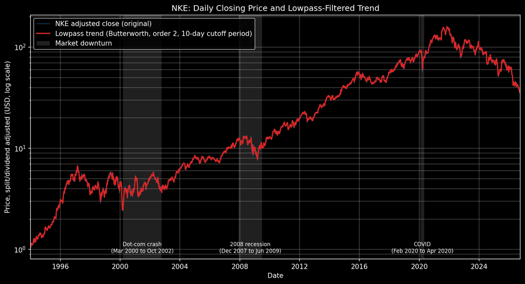

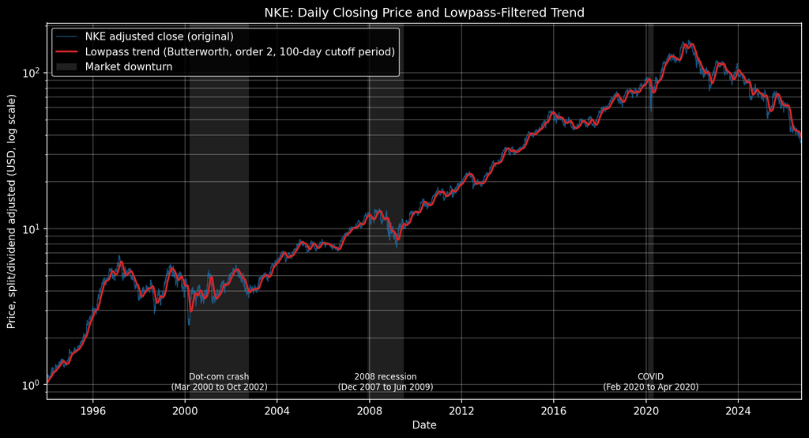

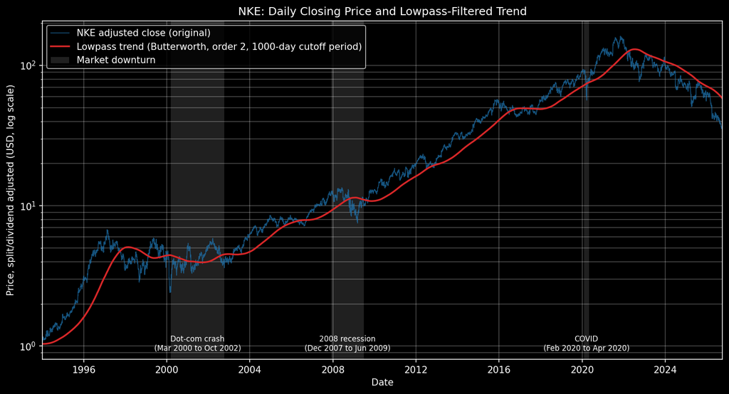

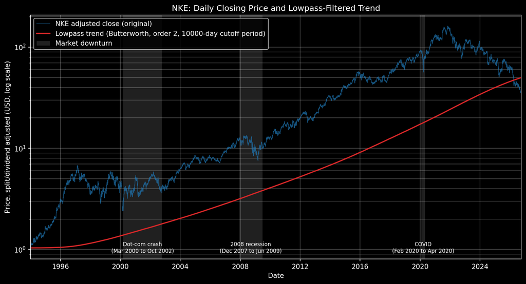

```python
import numpy as np
import pandas as pd
import matplotlib.pyplot as plt
from scipy import signal

# ----------------------------- Parameters ---------------------------------
CSV_PATH = "NKE.csv"
TICKER = "NKE"

# Filter design. Cutoff is specified as a period in trading days:
# a 100-day cutoff means components that vary slower than ~1 cycle per
# 100 trading days pass through; faster fluctuations are attenuated.
TEN_CUTOFF_PERIOD_DAYS = 10
HUNDRED_CUTOFF_PERIOD_DAYS = 100
THOUSAND_CUTOFF_PERIOD_DAYS = 1000
TEN_THOUSAND_CUTOFF_PERIOD_DAYS = 10000
FILTER_ORDER = 2

# Filtering log(price) treats a move from $1 -> $2 like $50 -> $100, which
# suits a stock that grew ~100x over the period. Set False to filter raw price.
FILTER_LOG_PRICE = True

FS = 1.0  # sampling rate: 1 sample per trading day


# Market downturns marked on the Problem 1 plots: (label, start date, end date).
MARKET_EVENTS = [
    ("Dot-com crash", "2000-03-10", "2002-10-09"),   # Nasdaq peak to trough
    ("2008 recession", "2007-12-01", "2009-06-30"),  # NBER recession dates
    ("COVID", "2020-02-01", "2020-04-30"),           # NBER recession dates
]


# ----------------------------- Load data ----------------------------------
def load_prices(path):
    """Load the daily price history saved by yfinance.

    Parameters
    ----------
    path : str
        Path to the CSV file written by ``df.to_csv`` in the cell above.

    Returns
    -------
    pandas.DataFrame
        Price data indexed by date (oldest first) with numeric columns
        Close, High, Low, Open, and Volume. Rows without a Close are dropped.
    """
    # yfinance CSV: row 0 = field names, row 1 = "Ticker" row, row 2 = "Date" row.
    # Skip the two extra header rows and name the index column explicitly.
    df = pd.read_csv(path, skiprows=[1, 2], index_col=0, parse_dates=True)
    df.index.name = "Date"
    df = df.apply(pd.to_numeric, errors="coerce").dropna(subset=["Close"])
    return df.sort_index()


# ----------------------------- Filter -------------------------------------
def lowpass_trend(x, cutoff_period_days, order=2, fs=1.0, log_price=True):
    """Causal Butterworth lowpass. Returns filtered signal in price units."""
    fc = 1.0 / cutoff_period_days           # cycles per day
    sos = signal.butter(order, fc, btype="low", fs=fs, output="sos")

    y = np.log(x) if log_price else np.asarray(x, dtype=float)

    # Initialize filter state as if the signal had always been at its first
    # value; avoids a large startup transient from zero initial conditions.
    zi = signal.sosfilt_zi(sos) * y[0]
    y_filt, _ = signal.sosfilt(sos, y, zi=zi)

    return np.exp(y_filt) if log_price else y_filt


# ----------------------------- Plot ---------------------------------------
def mark_market_events(ax, events=MARKET_EVENTS):
    """Shade and label major market downturns on a time domain plot.

    Parameters
    ----------
    ax : matplotlib.axes.Axes
        Axes with dates on the x-axis.
    events : list of tuple
        (label, start date, end date) for each downturn; dates are strings
        that pandas can parse.
    """
    for i, (label, start, end) in enumerate(events):
        start, end = pd.Timestamp(start), pd.Timestamp(end)
        ax.axvspan(start, end, color="gray", alpha=0.25, lw=0,
                   label="Market downturn" if i == 0 else None)
        ax.text(start + (end - start) / 2, 0.02,
                f"{label}\n({start:%b %Y} to {end:%b %Y})",
                transform=ax.get_xaxis_transform(), ha="center", va="bottom",
                fontsize=8)


def plot_signal_and_trend(dates, price, trend, cutoff_period_days):
    """Plot the original closing price and its lowpass-filtered trend.

    Parameters
    ----------
    dates : pandas.DatetimeIndex
        Trading dates for the x-axis.
    price : numpy.ndarray
        Adjusted daily closing prices (USD).
    trend : numpy.ndarray
        Lowpass-filtered price (USD), same length as ``price``.
    cutoff_period_days : int
        Filter cutoff period in trading days (used in the legend and file name).

    Returns
    -------
    matplotlib.figure.Figure
        The figure, which is also saved as a PNG in the working directory.
    """
    fig, ax = plt.subplots(figsize=(11, 6), dpi=150)

    ax.plot(dates, price, color="tab:blue", lw=0.8, alpha=0.7,
            label=f"{TICKER} adjusted close (original)")
    ax.plot(dates, trend, color="tab:red", lw=1.8,
            label=(f"Lowpass trend (Butterworth, order {FILTER_ORDER}, "
                   f"{cutoff_period_days}-day cutoff period)"))

    mark_market_events(ax)

    ax.set_yscale("log")  # price spans ~2 orders of magnitude
    ax.set_xlabel("Date")
    ax.set_ylabel("Price, split/dividend adjusted (USD, log scale)")
    ax.set_title(f"{TICKER}: Daily Closing Price and Lowpass-Filtered Trend")
    ax.grid(True, which="both", alpha=0.3)
    ax.legend(loc="upper left")
    ax.set_xlim(dates[0], dates[-1])

    fig.tight_layout()

    outfile = f"{cutoff_period_days}_days_price_and_trend.png"
    fig.savefig(outfile)
    print(f"Saved {outfile}")
    return fig


# ----------------------------- Main ---------------------------------------
if __name__ == "__main__":
    df = load_prices(CSV_PATH)
    price = df["Close"].to_numpy(dtype=float)
    dates = df.index

    print(f"Loaded {len(df)} rows: {dates[0].date()} to {dates[-1].date()}")

    trend10 = lowpass_trend(price, TEN_CUTOFF_PERIOD_DAYS, FILTER_ORDER, FS, FILTER_LOG_PRICE)
    trend100 = lowpass_trend(price, HUNDRED_CUTOFF_PERIOD_DAYS, FILTER_ORDER, FS, FILTER_LOG_PRICE)
    trend1000 = lowpass_trend(price, THOUSAND_CUTOFF_PERIOD_DAYS, FILTER_ORDER, FS, FILTER_LOG_PRICE)
    trend10000 = lowpass_trend(price, TEN_THOUSAND_CUTOFF_PERIOD_DAYS, FILTER_ORDER, FS, FILTER_LOG_PRICE)

    plot_signal_and_trend(dates, price, trend10, TEN_CUTOFF_PERIOD_DAYS)
    plot_signal_and_trend(dates, price, trend100, HUNDRED_CUTOFF_PERIOD_DAYS)
    plot_signal_and_trend(dates, price, trend1000, THOUSAND_CUTOFF_PERIOD_DAYS)
    plot_signal_and_trend(dates, price, trend10000, TEN_THOUSAND_CUTOFF_PERIOD_DAYS)

    plt.show()
```

## For the following problems, the 1000-day cutoff period will be used. This filter seems to balance growth with protection against global market downturns.

### Problem 2: Time domain plot of the growth of $1000 if you simply owned the equity the entire period.

```
Buy and hold: $1,000 on 1994-01-03 grows to $32,580 on 2026-10-02
Average annualized price return (compound): 11.23% per year
Mean daily return x 252 (arithmetic): 15.88% per year
```

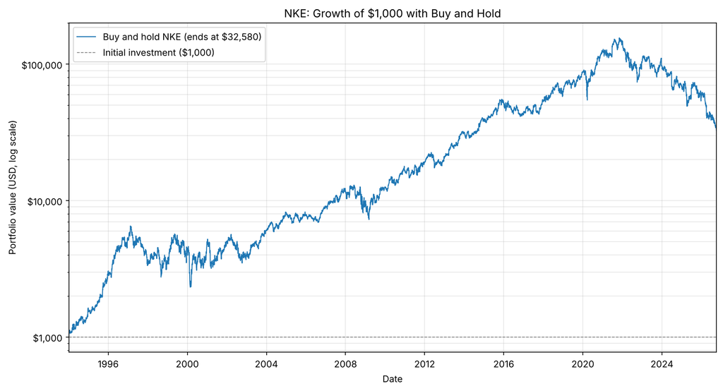

```python
from matplotlib.ticker import FuncFormatter

# ----------------------------- Parameters ---------------------------------
INITIAL_INVESTMENT = 1000.0      # USD invested on the first day
TRADING_DAYS_PER_YEAR = 252      # length of a "1 year period" in trading days

# The trend used for Problems 3-9 is the 1000-day cutoff filter from Problem 1.
TREND_CUTOFF_PERIOD_DAYS = THOUSAND_CUTOFF_PERIOD_DAYS
trend = trend1000


def buy_and_hold_value(price, initial=INITIAL_INVESTMENT):
    """Value of a buy and hold investment over time.

    Parameters
    ----------
    price : numpy.ndarray
        Adjusted daily closing prices.
    initial : float
        Amount invested at the first close (USD).

    Returns
    -------
    numpy.ndarray
        Portfolio value (USD) at each close, starting at ``initial``.
    """
    price = np.asarray(price, dtype=float)
    return initial * price / price[0]


def annualized_return(values, dates):
    """Compound annual growth rate of a portfolio value series.

    Parameters
    ----------
    values : numpy.ndarray
        Portfolio value at each close.
    dates : pandas.DatetimeIndex
        Dates matching ``values``; the elapsed calendar time sets the
        number of years.

    Returns
    -------
    float
        Annualized return as a fraction (0.10 means 10% per year).
    """
    years = (dates[-1] - dates[0]).days / 365.25
    return (values[-1] / values[0]) ** (1.0 / years) - 1.0


def format_dollar_axis(ax):
    """Label the y-axis ticks of ``ax`` as whole dollars (e.g. $10,000)."""
    ax.yaxis.set_major_formatter(FuncFormatter(lambda v, _: f"${v:,.0f}"))


def plot_buy_and_hold(dates, value):
    """Plot the growth of the initial investment under buy and hold.

    Parameters
    ----------
    dates : pandas.DatetimeIndex
        Trading dates for the x-axis.
    value : numpy.ndarray
        Buy and hold portfolio value (USD) at each close.

    Returns
    -------
    matplotlib.figure.Figure
        The figure, which is also saved as a PNG in the working directory.
    """
    fig, ax = plt.subplots(figsize=(11, 6), dpi=150)

    ax.plot(dates, value, color="tab:blue", lw=1.0,
            label=f"Buy and hold {TICKER} (ends at ${value[-1]:,.0f})")
    ax.axhline(INITIAL_INVESTMENT, color="gray", lw=0.8, ls="--",
               label=f"Initial investment (${INITIAL_INVESTMENT:,.0f})")

    ax.set_yscale("log")
    format_dollar_axis(ax)
    ax.set_xlabel("Date")
    ax.set_ylabel("Portfolio value (USD, log scale)")
    ax.set_title(f"{TICKER}: Growth of ${INITIAL_INVESTMENT:,.0f} with Buy and Hold")
    ax.grid(True, which="both", alpha=0.3)
    ax.legend(loc="upper left")
    ax.set_xlim(dates[0], dates[-1])

    fig.tight_layout()
    fig.savefig("buy_and_hold_growth.png")
    return fig


bh_value = buy_and_hold_value(price)
bh_cagr = annualized_return(bh_value, dates)
bh_daily_returns = price[1:] / price[:-1] - 1.0

print(f"Buy and hold: ${INITIAL_INVESTMENT:,.0f} on {dates[0].date()} "
      f"grows to ${bh_value[-1]:,.0f} on {dates[-1].date()}")
print(f"Average annualized price return (compound): {100 * bh_cagr:.2f}% per year")
print(f"Mean daily return x {TRADING_DAYS_PER_YEAR} (arithmetic): "
      f"{100 * bh_daily_returns.mean() * TRADING_DAYS_PER_YEAR:.2f}% per year")

plot_buy_and_hold(dates, bh_value)
plt.show()
```

### Problem 3: Time domain plot showing result of owning the equity only when the price is above the trend. Assume you start with $1000 investment at the beginning of the investment period.

```
Trend following (1000-day cutoff): $1,000 grows to $17,972
Annualized return (compound): 9.22% per year (buy and hold: 11.23%)
Time holding the equity: 68.9% of trading days
Number of trades (buys + sells): 118
```

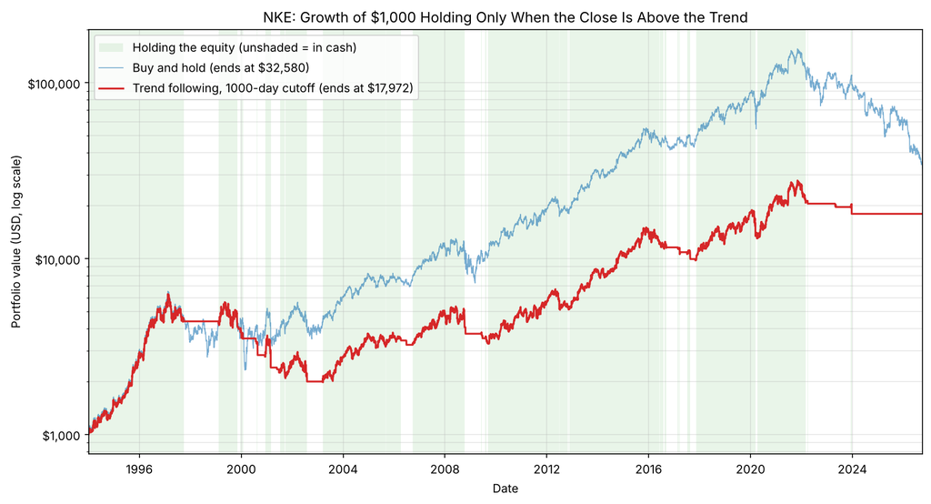

```python
TRADE_DELAY_DAYS = 1  # decide on day t's close, trade at day t+1's close


def trend_following_value(price, trend, initial=INITIAL_INVESTMENT,
                          delay=TRADE_DELAY_DAYS):
    """Simulate holding the equity only while the close is above the trend.

    The decision uses the close of day t (hold if price[t] > trend[t]). The
    trade happens ``delay`` trading days later at that day's close, so the
    first daily return affected by the decision is the one from day
    t + delay to day t + delay + 1. Money that is not invested sits in cash
    earning 0%. Transaction costs and taxes are ignored.

    Parameters
    ----------
    price : numpy.ndarray
        Adjusted daily closing prices.
    trend : numpy.ndarray
        Lowpass-filtered price, same length as ``price``.
    initial : float
        Starting cash (USD).
    delay : int
        Trading days between the signal and the trade.

    Returns
    -------
    value : numpy.ndarray
        Portfolio value (USD) at each close, starting at ``initial``.
    held : numpy.ndarray
        Boolean array; ``held[k]`` is True when the equity was owned from
        the close of day k-1 to the close of day k.
    """
    price = np.asarray(price, dtype=float)
    above_trend = price > np.asarray(trend, dtype=float)

    lag = delay + 1
    held = np.zeros(len(price), dtype=bool)
    held[lag:] = above_trend[:-lag]

    daily_return = np.zeros(len(price))
    daily_return[1:] = price[1:] / price[:-1] - 1.0

    value = initial * np.cumprod(1.0 + held * daily_return)
    return value, held


def count_trades(held):
    """Number of buy or sell transactions implied by a holding record."""
    return int(np.abs(np.diff(held.astype(int))).sum())


def plot_trend_following(dates, tf_value, bh_value, held, cutoff_period_days):
    """Plot trend following growth, with buy and hold shown for reference.

    Parameters
    ----------
    dates : pandas.DatetimeIndex
        Trading dates for the x-axis.
    tf_value : numpy.ndarray
        Trend following portfolio value (USD) at each close.
    bh_value : numpy.ndarray
        Buy and hold portfolio value (USD) at each close.
    held : numpy.ndarray
        Boolean array marking the days the equity was owned (shaded).
    cutoff_period_days : int
        Cutoff period of the trend filter, used in the legend.

    Returns
    -------
    matplotlib.figure.Figure
        The figure, which is also saved as a PNG in the working directory.
    """
    fig, ax = plt.subplots(figsize=(11, 6), dpi=150)

    ax.fill_between(dates, 0, 1, where=held, transform=ax.get_xaxis_transform(),
                    color="tab:green", alpha=0.10, lw=0,
                    label="Holding the equity (unshaded = in cash)")
    ax.plot(dates, bh_value, color="tab:blue", lw=0.8, alpha=0.6,
            label=f"Buy and hold (ends at ${bh_value[-1]:,.0f})")
    ax.plot(dates, tf_value, color="tab:red", lw=1.6,
            label=(f"Trend following, {cutoff_period_days}-day cutoff "
                   f"(ends at ${tf_value[-1]:,.0f})"))

    ax.set_yscale("log")
    format_dollar_axis(ax)
    ax.set_xlabel("Date")
    ax.set_ylabel("Portfolio value (USD, log scale)")
    ax.set_title(f"{TICKER}: Growth of ${INITIAL_INVESTMENT:,.0f} "
                 "Holding Only When the Close Is Above the Trend")
    ax.grid(True, which="both", alpha=0.3)
    ax.legend(loc="upper left")
    ax.set_xlim(dates[0], dates[-1])

    fig.tight_layout()
    fig.savefig("trend_following_growth.png")
    return fig


tf_value, tf_held = trend_following_value(price, trend)
tf_cagr = annualized_return(tf_value, dates)

print(f"Trend following ({TREND_CUTOFF_PERIOD_DAYS}-day cutoff): "
      f"${INITIAL_INVESTMENT:,.0f} grows to ${tf_value[-1]:,.0f}")
print(f"Annualized return (compound): {100 * tf_cagr:.2f}% per year "
      f"(buy and hold: {100 * bh_cagr:.2f}%)")
print(f"Time holding the equity: {100 * tf_held.mean():.1f}% of trading days")
print(f"Number of trades (buys + sells): {count_trades(tf_held)}")

plot_trend_following(dates, tf_value, bh_value, tf_held, TREND_CUTOFF_PERIOD_DAYS)
plt.show()
```

### Problem 4: Histogram of annual returns during 1 year periods of simply holding the equity.

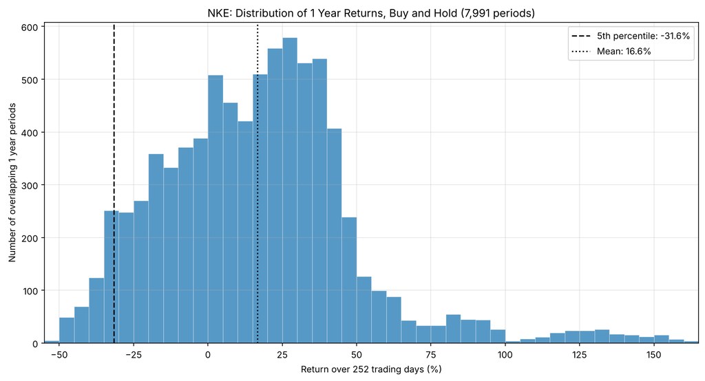

```python
def rolling_annual_returns(values, window=TRADING_DAYS_PER_YEAR):
    """Return over every overlapping 1 year segment of a value series.

    Each return is the percent change from the first day of a segment to
    the day ``window`` trading days later: (last - first) / first.
    Segments start on every trading day, so consecutive segments overlap.

    Parameters
    ----------
    values : numpy.ndarray
        Portfolio value (or price) at each close.
    window : int
        Segment length in trading days.

    Returns
    -------
    numpy.ndarray
        One return per segment, as a fraction (0.075 means 7.5%).
    """
    values = np.asarray(values, dtype=float)
    return values[window:] / values[:-window] - 1.0


def plot_return_histogram(returns, bins, strategy_name, color, outfile):
    """Histogram of 1 year returns with the 5th percentile and mean marked.

    Parameters
    ----------
    returns : numpy.ndarray
        1 year returns as fractions.
    bins : numpy.ndarray
        Histogram bin edges in percent.
    strategy_name : str
        Strategy label used in the title.
    color : str
        Bar color.
    outfile : str
        File name for the saved PNG.

    Returns
    -------
    matplotlib.figure.Figure
        The figure, which is also saved as a PNG in the working directory.
    """
    pct = 100.0 * returns
    p5 = np.percentile(pct, 5)
    mean = pct.mean()

    fig, ax = plt.subplots(figsize=(11, 6), dpi=150)
    ax.hist(pct, bins=bins, color=color, alpha=0.75, edgecolor="white", lw=0.3)
    ax.axvline(p5, color="black", lw=1.5, ls="--",
               label=f"5th percentile: {p5:.1f}%")
    ax.axvline(mean, color="black", lw=1.5, ls=":",
               label=f"Mean: {mean:.1f}%")

    ax.set_xlabel(f"Return over {TRADING_DAYS_PER_YEAR} trading days (%)")
    ax.set_ylabel("Number of overlapping 1 year periods")
    ax.set_title(f"{TICKER}: Distribution of 1 Year Returns, {strategy_name} "
                 f"({len(pct):,} periods)")
    ax.grid(True, alpha=0.3)
    ax.legend(loc="upper right")
    ax.set_xlim(bins[0], bins[-1])

    fig.tight_layout()
    fig.savefig(outfile)
    return fig


bh_annual = rolling_annual_returns(bh_value)
tf_annual = rolling_annual_returns(tf_value)

# Shared bin edges (5% wide) so the two histograms can be compared directly.
_lo = 5 * np.floor(100 * min(bh_annual.min(), tf_annual.min()) / 5)
_hi = 5 * np.ceil(100 * max(bh_annual.max(), tf_annual.max()) / 5)
RETURN_BINS = np.arange(_lo, _hi + 5, 5)

plot_return_histogram(bh_annual, RETURN_BINS, "Buy and Hold", "tab:blue",
                      "buy_and_hold_annual_returns.png")
plt.show()
```

### Problem 5: Histogram of annual returns during 1 year periods of trend following.

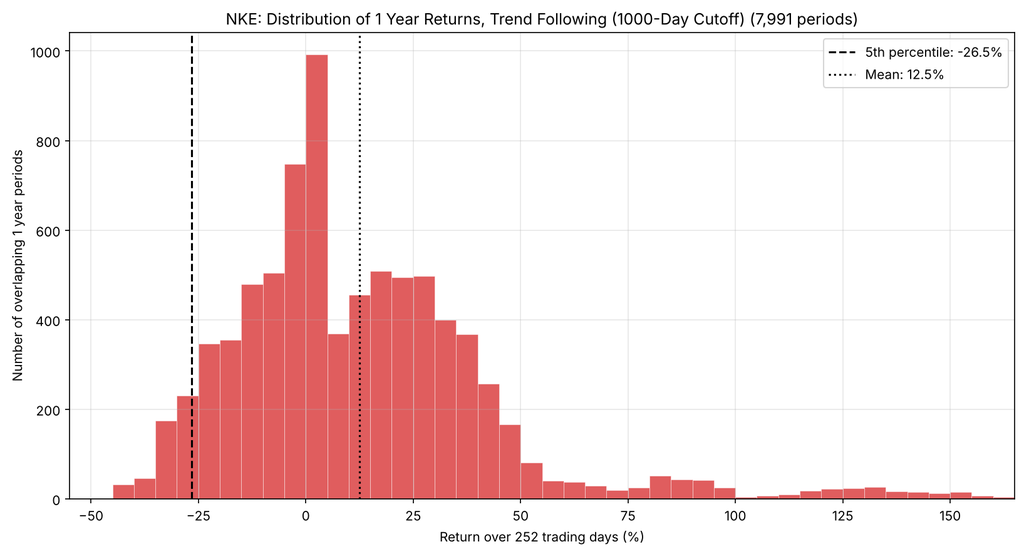

```python
plot_return_histogram(tf_annual, RETURN_BINS,
                      f"Trend Following ({TREND_CUTOFF_PERIOD_DAYS}-Day Cutoff)",
                      "tab:red", "trend_following_annual_returns.png")
plt.show()
```

### Problem 6: Report the average 5th percentile over consecutive 1 year periods for buy and hold

```python
def summarize_annual_returns(returns, strategy_name):
    """Print the 5th percentile and other summary statistics of 1 year returns.

    Parameters
    ----------
    returns : numpy.ndarray
        1 year returns as fractions.
    strategy_name : str
        Label printed with the statistics.

    Returns
    -------
    float
        The 5th percentile of ``returns`` as a fraction.
    """
    p5 = np.percentile(returns, 5)
    print(f"{strategy_name}: {len(returns):,} overlapping 1 year periods")
    print(f"  5th percentile of 1 year returns: {100 * p5:.2f}%")
    print(f"  Mean 1 year return:               {100 * returns.mean():.2f}%")
    print(f"  Median 1 year return:             {100 * np.median(returns):.2f}%")
    print(f"  Periods with a positive return:   {100 * (returns > 0).mean():.1f}%")
    return p5


bh_p5 = summarize_annual_returns(bh_annual, "Buy and hold")
```

```
Buy and hold: 7,991 overlapping 1 year periods
  5th percentile of 1 year returns: -31.61%
  Mean 1 year return:               16.62%
  Median 1 year return:             16.45%
  Periods with a positive return:   69.1%
```

**Answer:** Across all 7,991 overlapping 1 year (252 trading day) periods from 1994 to 2026, the 5th percentile of the buy and hold return is **-31.61%**. In other words, in 5% of the 1 year periods buy and hold lost more than 31.61%. The mean 1 year return was 16.62%, and 69.1% of the periods had a positive return.

### Problem 7: Report the average 5th percentile over consecutive 1 year periods for trend following

```python
tf_p5 = summarize_annual_returns(
    tf_annual, f"Trend following ({TREND_CUTOFF_PERIOD_DAYS}-day cutoff)")
```

```
Trend following (1000-day cutoff): 7,991 overlapping 1 year periods
  5th percentile of 1 year returns: -26.53%
  Mean 1 year return:               12.51%
  Median 1 year return:             6.38%
  Periods with a positive return:   56.7%
```

**Answer:** Across the same 7,991 overlapping 1 year periods, the 5th percentile of the trend following return (1000-day cutoff) is **-26.53%**, about 5 percentage points better than buy and hold (-31.61%). The mean 1 year return was 12.51%, and 56.7% of the periods had a positive return. The tall bar near 0% in the Problem 5 histogram comes from the periods spent mostly or entirely in cash.

### Problem 8: Write a brief explanation of how you designed and/or optimized the filter that you applied to estimate the trend

```python
def max_drawdown(values):
    """Largest peak-to-trough decline of a value series, as a negative fraction."""
    values = np.asarray(values, dtype=float)
    return (values / np.maximum.accumulate(values) - 1.0).min()


def compare_cutoffs(price, dates, trends):
    """Tabulate trend following performance for each candidate cutoff period.

    Parameters
    ----------
    price : numpy.ndarray
        Adjusted daily closing prices.
    dates : pandas.DatetimeIndex
        Dates matching ``price``.
    trends : dict
        Maps cutoff period in trading days to the filtered price array.

    Returns
    -------
    pandas.DataFrame
        One row for buy and hold and one per cutoff period.
    """
    rows = {}
    bh = buy_and_hold_value(price)
    candidates = [("Buy and hold", bh, np.ones(len(price), dtype=bool))]
    for period, tr in trends.items():
        value, held = trend_following_value(price, tr)
        candidates.append((f"{period}-day cutoff", value, held))

    for name, value, held in candidates:
        annual = rolling_annual_returns(value)
        rows[name] = {
            "Final value ($)": round(value[-1]),
            "Annualized return (%)": round(100 * annualized_return(value, dates), 2),
            "Mean 1 yr return (%)": round(100 * annual.mean(), 2),
            "5th pct 1 yr return (%)": round(100 * np.percentile(annual, 5), 2),
            "Max drawdown (%)": round(100 * max_drawdown(value), 1),
            "Time invested (%)": round(100 * held.mean(), 1),
            "Trades": 0 if name == "Buy and hold" else count_trades(held),
        }
    table = pd.DataFrame(rows).T
    return table.astype({"Final value ($)": int, "Trades": int})


cutoff_table = compare_cutoffs(price, dates, {
    TEN_CUTOFF_PERIOD_DAYS: trend10,
    HUNDRED_CUTOFF_PERIOD_DAYS: trend100,
    THOUSAND_CUTOFF_PERIOD_DAYS: trend1000,
    TEN_THOUSAND_CUTOFF_PERIOD_DAYS: trend10000,
})
print(cutoff_table.to_string())
```

```
                  Final value ($)  Annualized return (%)  Mean 1 yr return (%)  5th pct 1 yr return (%)  Max drawdown (%)  Time invested (%)  Trades
Buy and hold                32580                  11.23                 16.62                   -31.61             -79.1              100.0       0
10-day cutoff                 597                  -1.56                  1.72                   -35.51             -79.4               52.7    2162
100-day cutoff               6653                   5.96                  9.02                   -25.92             -56.4               59.7     568
1000-day cutoff             17972                   9.22                 12.51                   -26.53             -68.5               68.9     118
10000-day cutoff            40290                  11.95                 16.66                   -31.61             -73.2               98.4       2
```

I estimated the trend with a causal 2nd order Butterworth lowpass filter applied to the log of the daily closing price. The Butterworth passband is maximally flat, the low order keeps the delay small, and filtering forward only (`sosfilt`) means the trend never uses future prices. The only parameter I tuned was the cutoff period, comparing 10, 100, 1000, and 10000 trading days. The 10-day filter traded constantly and lost money, the 100-day filter protected well but gave up most of the growth, and the 10000-day filter behaved almost exactly like buy and hold. I chose the 1000-day cutoff as the best balance between growth and protection from dips, at the cost of a lag of roughly 225 trading days.

### Problem 9: What do you conclude about the feasibility of using your trend following algorithm? Are there risk/reward tradeoffs in using this strategy as compared to buy and hold?

The algorithm is feasible to run because it is causal, trades one day after the signal, and only made 118 trades in almost 33 years. However, it did not beat buy and hold on total return: 1,000 USD grew to 17,972 USD (I had problems with the dollar sign here) compared to $32,580, or 9.22% per year compared to 11.23%. In exchange, the bad years were less severe, with the 5th percentile 1 year return improving from -31.61% to -26.53% and the maximum drawdown shrinking from -79.1% to -68.5%. The protection is limited, since the 5th percentile is still well below zero and the filter's lag means it sells and buys back late. The results also ignore transaction costs, taxes, and interest on cash, and were tuned and tested on the same single stock, so they may not generalize.

### Problem 10: What, if anything, did you learn from this homework?

I completely misunderstood what the graphs in Problem 1 were telling me. I took the resulting graphs as the actual realized values rather than just a trend that the realized values would follow. With this clarification, it makes sense now why the chosen trend ended up with only half the original value since the trend was below the market values for over half the time.

I also learned that one could apply signal filters to a lot more than actual signals.

### Problem 11: What new questions, if any, do you have?

I have no questions at this time.